# Figure 2 - Overview heatmaps for IP-MS and ChIP

Charlotte Soneson, Michael Stadler, Merle Skribbe

2024-07-04

# Parameter values

```r
params
```

```
## $rds150
## [1] "data/ipms_150_sce.rds"
##
## $rds500
## [1] "data/ipms_500_sce.rds"
##
## $complexes
## [1] "data/complexes.json"
##
## $idmap
## [1] "data/id_mapping_table.txt"
##
## $baitclass
## [1] "data/ipms_bait_class.txt"
##
## $dbdtxt
## [1] "data/TF_DBD_annotation.txt"
##
## $peakcsv
## [1] "data/fused_peaks_filtered.csv.gz"
##
## $peakenr
## [1] "data/fused_peaks_filtered_enrichments.csv.gz"
##
## $peakatacfile
## [1] "data/fused_peaks_filtered_counts-external_atac.csv.gz"
##
## $peakchipfile
## [1] "data/fused_peaks_filtered_counts-external_chip.csv.gz"
##
## $gtf
## [1] "reference/Schizosaccharomyces_pombe.ASM294v2.55.gtf"
```

# Load required packages and helper functions

```r
suppressPackageStartupMessages({
    library(SingleCellExperiment)
    library(ggplot2)
    library(cowplot)
    library(dplyr)
    library(forcats)
    library(jsonlite)
    library(ComplexHeatmap)
    library(colorspace)
    library(circlize)
    library(scattermore)
    # library(ggrepel)
    # library(DT)
    # library(stringr)
    library(tidyr)
    # library(kableExtra)
    # library(patchwork)
})

## Source scripts with required helper functions and settings
source("params/plot_settings.R")
source("params/get_testres_function.R")
source("params/ipms_params.R")
source("params/mapping_functions.R")

## Heatmap sizes
w_ipmsHm <-  84 # heatmap body width (mm)
h_ipmsHm <- 178 # total heatmap height (mm)
w_peaksHm <-  84 # heatmap body width (mm)
h_peaksHm <- 178 # total heatmap height (mm)

fs <- 8  # small font size
fm <- 9  # medium font size
fl <- 10 # large font size
ft <- 12 # title font size
```

# Read data

## IP-MS

We load two `SingleCellExperiment` objects, containing data and results from the low- and high-salt experiments, respectively.

```r
sce150 <- readRDS(params$rds150)
sce500 <- readRDS(params$rds500)
```

We then extract the full list of baits, as well as a classification according to the experiment(s) where a certain bait was pulled down.

```r
idmap <- read.delim(params$idmap)
baitclass <- read.delim(params$baitclass)
```

In the following set of IPs, we identified the bait as not pulled down.

```r
(nobait_150 <- baitclass$Gene_name[baitclass$class == "nobait"])
```

```
## [1] "Cha4"        "Cuf2"        "Atf21"       "Cbf12"       "Sre2"        "SPBC1348.12" "Untagged"
```

We also read a list of known complexes, which will be used for annotation purposes.

```r
complexes <- jsonlite::read_json(params$complexes, simplifyVector = TRUE)
complexes$`MBF transcription complex`$color <- main_colors[5]
complexes$`CCAAT-binding factor complex`$color <- main_colors[1]
complexes$`Atf1-Pcr1`$color <- main_colors[3]
names(complexes)
```

```
##  [1] "NuA4"                            "SAGA"                            "19S proteasome - base"
##  [4] "Clr6 HDAC - complex I'"          "SREBP-SCAP"                      "SPBC16G5.16-SPBC530.08"
##  [7] "Atf1-Pcr1"                       "chaperonin-containing T-complex" "CCAAT-binding factor complex"
## [10] "Dal2"                            "Cyc8(Ssn6)-Tup1"                 "Rad24-Rad25"
## [13] "Ste11-Cdc2-Cig2"                 "Pap1-Prr1"                       "MBF transcription complex"
```

Finally we load a table classifying each TF to its DNA-binding domain family.

```r
dbd <- read.delim(params$dbdtxt) |>
    dplyr::mutate(Gene_name = .capitalize(Gene_name))
```

## ChIP

We start by reading all tables and objects needed for the ChIP part of the figure. Count tables are in addition normalized, and we also calculate averages over replicates or all samples where needed:

```r
# `peakgr`: ChIP-seq peaks (as a GRanges object)
peakgr <- as(read.csv(params$peakcsv, row.names = 1), "GRanges")
peakgr$peaktype <- factor(peakgr$peaktype,
                          levels = c("common peaks (ubiquitous)",
                                     "common peaks (frequent)",
                                     "specific peaks"))

# `peakenr`: peak IP-enrichments log2(IP/input)
peakenr <- as.matrix(read.csv(params$peakenr, row.names = 1))


# ... average replicates (`peakenrAvg`)
grp <- sub("_rep[12]$", "", colnames(peakenr))
peakenrAvg <- do.call(cbind, lapply(split(colnames(peakenr), grp)[unique(grp)],
                                    function(j) {
                                        rowMeans(peakenr[, j, drop = FALSE])
                                    }))

# `atac_raw`: public ATAC-seq read counts in ChIP-seq peaks from this study
atac_raw <- as.matrix(read.csv(params$peakatacfile, row.names = 1))

# ... calculate reads per million (`atac_cpm`) and
#     per kilobase and million (`atac_rpkm`)
#     and average experiments (`atac_cpm_avg`, `atac_rpkm_avg`)
atac_cpm <- sweep(x = atac_raw[, -1], MARGIN = 2,
                  STATS = colSums(atac_raw[, -1]), FUN = "/") * 1e6
atac_rpkm <- atac_cpm / atac_raw[, "width"] * 1e3
atac_cpm_avg <- rowMeans(atac_cpm)
atac_rpkm_avg <- rowMeans(atac_rpkm)

# `chip_raw`: public ChIP-seq read counts in ChIP-seq peaks from this study
chip_raw <- as.matrix(read.csv(params$peakchipfile, row.names = 1))

# ... calculate reads per million (`chip_cpm`) and
#     per kilobase and million (`chip_rpkm`)
#     and calculate enrichments (`chip_enr`, log2 IP/input) averaged over replicates
chip_cpm <- sweep(x = chip_raw[, -1], MARGIN = 2,
                  STATS = colSums(chip_raw[, -1]), FUN = "/") * 1e6
chip_rpkm <- chip_cpm / chip_raw[, "width"] * 1e3
chip_series <- sub("^ChIP_([^_]+)_.+$", "\\1", colnames(chip_cpm))
chip_enr <- do.call(
    cbind,
    lapply(split(colnames(chip_cpm), chip_series),
           function(nms) {
               grp <- sub("ChIP_(GSE[0-9]+)_GSM[0-9]+_(.+)_rep[0-9]$",
                          "\\1_\\2", nms)
               stopifnot(any(is_input <- grep("_Input", grp)))
               enr <- do.call(
                   cbind,
                   lapply(unique(grp[-is_input]), function(grp1) {
                       rowMeans(log2(chip_cpm[, nms[grp == grp1], drop = FALSE] + 1)) -
                           rowMeans(log2(chip_cpm[, nms[is_input], drop = FALSE] + 1))
                   }))
               colnames(enr) <- unique(grp[-is_input])
               enr
           }))


# `genegr`: chromosomal ranges of genes (as GRanges object)
genegr <- rtracklayer::import(params$gtf, feature.type = "gene")
```

# Helper functions

We define a number of additional helper functions for data extraction and summarization, which will be used below.

```r
filterForHeatmap <- function(tstatmat, adjpmat, logfcmat, adjpThreshold,
                             logfcThreshold, maxNbrTargets) {
    ## Filter - require significant in at least one comparison
    tstatfilt <- tstatmat
    tstatfilt[adjpmat >= adjpThreshold] <- NA
    tstatfilt[logfcmat <= logfcThreshold] <- NA
    # tstatfilt[tstatfilt <= 0] <- NA

    ## Some experiments pull down a large number of proteins
    # print(table(colSums(!is.na(tstatfilt))))
    ## -> remove proteins that are only being pulled down in these experiments
    keep <- which(colSums(!is.na(tstatfilt)) <= maxNbrTargets)
    tstatfilt <- tstatfilt[rowSums(!is.na(tstatfilt[, keep])) > 0, ]
    tstatfilt[is.na(tstatfilt)] <- 0
    tstatfilt <- tstatfilt[rowSums(tstatfilt) > 0, ]

    ## Subset the t-statistic matrix to only the retained proteins
    stopifnot(colnames(tstatfilt) == colnames(tstatmat))
    tstatmat <- tstatmat[rownames(tstatfilt), colnames(tstatfilt)]
    colnames(tstatmat) <- .getSimplifiedComparison(colnames(tstatmat))

    list(tstats = tstatmat, tstatsfilt = tstatfilt)
}

makeComplexAnnotation <- function(tstatmat, complexes, idmap,
                                  show_legend = TRUE) {
    rowannot <- data.frame(Complex = rep(NA, nrow(tstatmat)),
                           row.names = rownames(tstatmat))
    rowcols <- list(Complex = c())
    for (cmplx in names(complexes)) {
        rowannot$Complex[.getPomBaseIdFromProtein(rownames(rowannot),
                                                  idmap = idmap) %in%
                             complexes[[cmplx]]$pombase_ids] <- cmplx
        rowcols$Complex[cmplx] <- complexes[[cmplx]]$color
    }
    rowAnnotation(df = rowannot,
                  col = rowcols,
                  annotation_name_gp = gpar(fontsize = fl),
                  simple_anno_size_adjust = TRUE,
                  na_col = bg_color,
                  show_annotation_name = FALSE,
                  show_legend = show_legend,
                  annotation_legend_param = list(title_gp = gpar(fontsize = fl)))
}

makeColLabels <- function(tstatmat, colLabel, fontsize) {
    columnAnnotation(
        TFnames = anno_mark(which = "column", side = "bottom",
                            at = match(colLabel, colnames(tstatmat)),
                            labels = .getProteinNameFromSimplifiedComparison(colLabel),
                            labels_gp = gpar(fontsize = fontsize)))
}

makeHeatmapCol <- function(tstatmat, stringency = "high") {
    if (stringency == "high") {
        circlize::colorRamp2(
            breaks = seq(3.0, 13.0, length.out = 64),
            colors = colorRampPalette(binary_heatmap_colors[c("FALSE", "TRUE")])(64))
    } else {
        circlize::colorRamp2(
            breaks = seq(1.5, 13.0, length.out = 64),
            colors = colorRampPalette(binary_heatmap_colors[c("FALSE", "TRUE")])(64))
    }
}

reorderColsByRows <- function(tstat) {
    ## Row names should be protein names, column names simplified comparison names
    ord <- match(rownames(tstat), .getProteinNameFromSimplifiedComparison(colnames(tstat)))
    ord <- ord[!is.na(ord)]
    ord <- c(ord, setdiff(seq_len(ncol(tstat)), ord))
    tstat[, ord]
}

makeHeatmapData <- function(sce, adjpthr, log2fcthr, conc) {
    tc <- .getTestCols(sce, adjp_cutoff = adjpthr, logfc_cutoff = log2fcthr)

    tstats <- filterForHeatmap(tstatmat = tc$tstat, adjpmat = tc$adjp,
                               logfcmat = tc$logfc, logfcThreshold = log2fcthr,
                               adjpThreshold = adjpthr, maxNbrTargets = Inf)
    tstat <- tstats$tstats

    ## tstats$tstatsfile: protein x experiment
    ## Number of TFs that are pulled down by each bait
    all_tfs <- setdiff(.getProteinNameFromComparison(colnames(tstats$tstatsfilt)),
                       c("Untagged", "untagged", NA))
    nbrInt <- colSums(tstats$tstatsfilt[rownames(tstats$tstatsfilt) %in% all_tfs, ] > 0,
                      na.rm = TRUE)
    names(nbrInt) <- .getSimplifiedComparison(names(nbrInt))

    ## Split by family - return a matrix with several columns:
    ## #pulled down TFs (including itself), #pulled down TFs (excluding itself),
    ## #pulled down TFs from the same family (excluding itself),
    ## #pulled down TFs from another family
    tmptf <- tstats$tstatsfilt[match(.getProteinNameFromComparison(colnames(tstats$tstatsfilt)),
                                     rownames(tstats$tstatsfilt)), ]
    rownames(tmptf) <- .getProteinNameFromComparison(colnames(tstats$tstatsfilt))
    dbdtf <- data.frame(PomBaseID = .getPomBaseIdFromComparison(colnames(tstats$tstatsfilt),
                                                                idmap = idmap),
                        bait = .getProteinNameFromComparison(colnames(tstats$tstatsfilt)),
                        DBD_class = NA)
    for (i in seq_len(nrow(dbdtf))) {
        lookfor <- dbdtf$PomBaseID[i]
        if (!(lookfor %in% c("untagged", "Untagged"))) {
            dbdtf$DBD_class[i] <- dbd$DBD_class[match(lookfor, dbd$PomBaseID)]
        } else {
            dbdtf$DBD_class[i] <- "no_class"
        }
    }
    stopifnot(dbdtf$bait == .getProteinNameFromComparison(colnames(tmptf)))
    nbrIntMat <- do.call(dplyr::bind_rows, lapply(seq_along(colnames(tmptf)), function(i) {
        expr <- colnames(tmptf)[i]
        fam <- dbdtf$DBD_class[i]
        data.frame(experiment = expr,
                   bait = dbdtf$bait[i],
                   dbdfam = fam,
                   TFs = paste(rownames(tmptf)[-i][which(tmptf[-i, expr] > 0)],
                               collapse = ","),
                   nbrTFs = sum(tmptf[, expr] > 0, na.rm = TRUE),
                   nbrTFs_wobait = sum(tmptf[-i, expr] > 0, na.rm = TRUE),
                   nbrTFs_samefam = sum(tmptf[-i, expr] > 0 &
                                            dbdtf$DBD_class[-i] == fam,
                                        na.rm = TRUE),
                   nbrTFs_difffam = sum(tmptf[-i, expr] > 0 &
                                            dbdtf$DBD_class[-i] != fam,
                                        na.rm = TRUE)
        )
    }))


    ## Split experiments into three groups
    if (conc == 150) {
        stopifnot(all(colnames(tstat) == .getSimplifiedComparison(colnames(tstats$tstatsfilt))))
        tstat_no_bait <-
            tstat[, colSums(tstats$tstatsfilt) == 0 |
                      (.getOrigBaitNameFromComparison(colnames(tstats$tstatsfilt), idmap = idmap) %in%
                      baitclass$Gene_name[baitclass$class == "nobait"])]
        tstat_150only <-
            tstat[, colSums(tstats$tstatsfilt) > 0 &
                      (.getOrigBaitNameFromComparison(colnames(tstats$tstatsfilt), idmap = idmap) %in%
                      baitclass$Gene_name[baitclass$class == "150only"])]
        tstat_150and500 <-
            tstat[, colSums(tstats$tstatsfilt) > 0 &
                      (.getOrigBaitNameFromComparison(colnames(tstats$tstatsfilt), idmap = idmap) %in%
                      baitclass$Gene_name[baitclass$class == "150and500"])]

        proteins_150only <- .getProteinNameFromSimplifiedComparison(colnames(tstat_150only))
        stopifnot(all(proteins_150only %in% rownames(tstat)))
        tstat_150and500 <- tstat_150and500[!(rownames(tstat_150and500) %in% proteins_150only), ]

        ## Cluster proteins based on the correlation between their t-stat vectors
        dst <- sqrt(2 * (1 - cor(t(tstat_150and500), use = "pairwise.complete")))
        dst[is.na(dst)] <- sqrt(2 * (1 - (-1)))
        clst <- hclust(as.dist(dst))

        ## Reorder proteins by the clustering
        protorder <- c(rownames(tstat_150and500)[clst$order], proteins_150only)
        tstat <- tstat[protorder, ]

        ## Reorder experiments to keep a "diagonal" in the heatmap
        tstat <- reorderColsByRows(tstat)

        tmpbaits <- .getOrigBaitNameFromSimplifiedComparison(colnames(tstat),
                                                             idmap = idmap)
        colsplit <- ifelse(
            tmpbaits %in% baitclass$Gene_name[baitclass$class == "nobait"],
            "No\nbait",
            ifelse(
                tmpbaits %in% baitclass$Gene_name[baitclass$class == "150only"],
                "150 mM NaCl",
                ifelse(
                    tmpbaits %in% baitclass$Gene_name[baitclass$class == "150and500"],
                    "150 and\n500 mM NaCl", "NA"
                )
            )
        )
    } else if (conc == 500) {
        tstat_onlybait <-
            tstat[, colSums(tstats$tstatsfilt > 0) == 1 |
                      (.getOrigBaitNameFromComparison(colnames(tstats$tstatsfilt),
                                                      idmap = idmap) %in%
                      baitclass$Gene_name[baitclass$class500 == "Lost in 500 mM"])]
        tstat_several <-
            tstat[, colSums(tstats$tstatsfilt > 0) > 1 &
                      (.getOrigBaitNameFromComparison(colnames(tstats$tstatsfilt),
                                                      idmap = idmap) %in%
                      baitclass$Gene_name[baitclass$class500 != "Lost in 500 mM"])]
        tstat_onlybait <- tstat_onlybait[, colnames(tstat_onlybait) != "Untagged_plate"]
        tstat_several <- tstat_several[, colnames(tstat_several) != "Untagged_plate"]

        proteins_onlybait <-
            .getProteinNameFromSimplifiedComparison(colnames(tstat_onlybait))
        stopifnot(all(proteins_onlybait %in% rownames(tstat)))
        tstat_several <- tstat_several[!(rownames(tstat_several) %in% proteins_onlybait), ]

        ## Cluster proteins based on the correlation between their t-stat vectors
        dst <- sqrt(2 * (1 - cor(t(tstat_several), use = "pairwise.complete")))
        dst[is.na(dst)] <- sqrt(2 * (1 - (-1)))
        clst <- hclust(as.dist(dst))

        ## Reorder proteins by the clustering
        protorder <- c(rownames(tstat_several)[clst$order], proteins_onlybait)
        tstat <- tstat[protorder, ]

        ## Reorder conditions to keep a "diagonal" in the heatmap
        tstat <- reorderColsByRows(tstat)

        colsplit <- factor(
            structure(baitclass$class500[
                match(.getOrigBaitNameFromSimplifiedComparison(colnames(tstat),
                                                               idmap = idmap),
                      baitclass$Gene_name)],
                names = colnames(tstat)),
            levels = c("Retained in 500 mM", "Lost in 500 mM", ""))
        levels(colsplit) <- c("Interactions\nin 500 mM NaCl",
                              "No interactions\nin 500 mM NaCl", "")
    } else {
        stop("Unknown concentration")
    }
    return(list(tstat = tstat, colsplit = colsplit, nbrIntMat = nbrIntMat))
}

# for each region in `from`, calculate the distance to its nearest element in `to`
# if there are no element in `to` on the sequence of `from`, set distance to NA
calcDistanceToNearest <- function(from, to) {
    stopifnot(exprs = {
        is(from, "GRanges")
        is(to, "GRanges")
    })
    tmp <- distanceToNearest(x = from, subject = to)
    d <- rep(NA, length(from))
    d[queryHits(tmp)] <- mcols(tmp)$distance
    return(d)
}
```

# Extract data for IP-MS heatmaps

```r
hmdata_150 <- makeHeatmapData(sce = sce150, adjpthr = adjpThreshold,
                              log2fcthr = log2fcThreshold, conc = 150)
hmdata_500 <- makeHeatmapData(sce = sce500, adjpthr = adjpThreshold,
                              log2fcthr = log2fcThreshold, conc = 500)
```

# Calculate peak distances to tRNA or rRNA genes

We want to identify ChIP-seq peaks that are near a tRNA or rRNA gene. We can obtain the coordinates of these genes from `genegr` and the coordinates of peaks from `peakgr`, and calculate the distance between nearest peak-gene pairs using `distanceToNearest()`. Any pair with a distance below `maxdist` will be classified as “near” in the plots below.

Remark: Nearest distances can be `NA` in cases where for example a peak resides on a sequence (chromosome) that does not contain any tRNA or rRNA gene, or vice versa, such as the sequence `AB325691` (which contains gap-filling sequence between SPBPB21E7.09 and SPBPB10D8.01 in chromosome 2) or the mitochondrial sequence `MT`.

```r
# distance less than `maxdist` are defined as "near"
maxdist <- 100

# tRNA
# ... PomBase and Ensembl_Fungi annotate 196 and 183 tRNAs, respectively
#     we combine the two and obtain 198 annotated tRNAs
table(genegr$gene_biotype == "tRNA", genegr$source)
```

```
##
##         PomBase Ensembl_Fungi
##   FALSE    6818            71
##   TRUE      196           183
```

```r
is_tRNA_pombase <- genegr$source == "PomBase" & genegr$gene_biotype == "tRNA"
is_tRNA_ensembl <- genegr$source == "Ensembl_Fungi" & genegr$gene_biotype == "tRNA"
is_tRNA <- is_tRNA_pombase | (is_tRNA_ensembl & !genegr %in% genegr[is_tRNA_pombase])
sum(is_tRNA)
```

```
## [1] 198
```

```r
# ... now we measure distances between nearest pairs
#     either from peak to nearest tRNA
dist.peak2tRNA <- calcDistanceToNearest(from = peakgr, to = genegr[is_tRNA])
#     or from tRNA to nearest peak
dist.tRNA2peak <- calcDistanceToNearest(from = genegr[is_tRNA], to = peakgr)

# rRNA
# ... all 36 5S_rRNA genes in our annotation stem from Ensembl_Fungi
table(genegr$gene_name == "5S_rRNA", genegr$source)
```

```
##
##         PomBase Ensembl_Fungi
##   FALSE    4524           218
##   TRUE        0            36
```

```r
is_rRNA <- !is.na(genegr$gene_name) & genegr$gene_name == "5S_rRNA"
sum(is_rRNA)
```

```
## [1] 36
```

```r
# ... now we measure distances between nearest pairs
#     either from peak to nearest rRNA
dist.peak2rRNA <- calcDistanceToNearest(from = peakgr, to = genegr[is_rRNA])
#     or from rRNA to nearest peak
dist.rRNA2peak <- calcDistanceToNearest(from = genegr[is_rRNA], to = peakgr)
```

# Figure 2

## Settings

```r
colLabel_150 <- expand.grid(c("Untagged", "Ace2", "Rst2", "Pap1"),
                            c("tube", "plate")) |>
    tidyr::unite(col = "col", Var1, Var2) |>
    dplyr::pull(col)
colLabel_500 <- expand.grid(c("Untagged", "Atf1", "Moc3", "Ntu1",
                              "Pcr1", "Ntu2"),
                            c("tube", "plate")) |>
    tidyr::unite(col = "col", Var1, Var2) |>
    dplyr::pull(col)
rowLabel <- NULL

complexLabel <- c("NuA4", "SAGA")
```

## Summary heatmaps using results from the statistical tests (150 mM NaCl)

### Overall heatmap

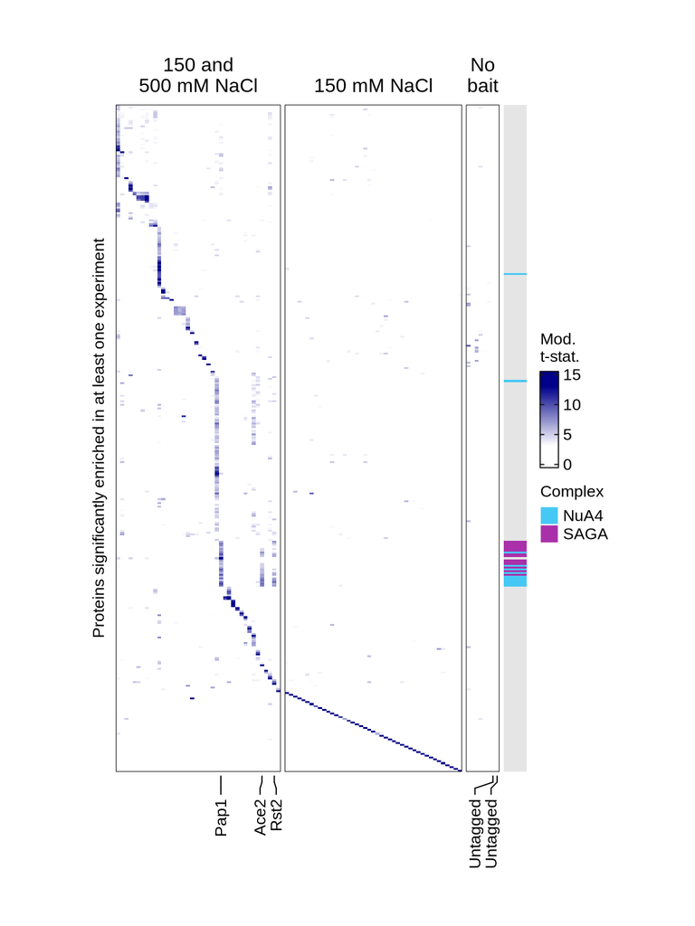

```r
hm1a <- Heatmap(hmdata_150$tstat,
                cluster_rows = FALSE,
                cluster_columns = FALSE,
                col = makeHeatmapCol(hmdata_150$tstat, stringency = "high"),
                border = TRUE,
                border_gp = gpar(lwd = 0.5),
                column_split = hmdata_150$colsplit,
                name = "Mod.\nt-stat.",
                na_col = binary_heatmap_colors["FALSE"],
                column_names_gp = gpar(fontsize = fs),
                row_names_gp = gpar(fontsize = fs),
                row_title = "Proteins significantly enriched in at least one experiment",
                row_title_gp = gpar(fontsize = fl),
                show_row_names = FALSE, show_column_names = FALSE,
                use_raster = FALSE, show_heatmap_legend = TRUE,
                right_annotation = makeComplexAnnotation(
                    hmdata_150$tstat, complexes[complexLabel],
                    idmap = idmap),
                bottom_annotation = makeColLabels(hmdata_150$tstat, colLabel_150, fl),
                width = unit(w_ipmsHm, "mm"), # heatmap body width
                heatmap_height = unit(h_ipmsHm, "mm"), # whole heatmap height
                column_title_gp = gpar(fontsize = ft),
                heatmap_legend_param = list(title_gp = gpar(fontsize = fl),
                                border = "gray10",
                                border_gp = gpar(lwd = 0.5)))

set.seed(42L)
hm_150 <- grid.grabExpr(
    hm1a <- draw(hm1a, merge_legend = TRUE,
                heatmap_legend_side = "right",
                annotation_legend_side = "right"),
    width = w_ipmsHm, height = h_ipmsHm
)

plot_grid(hm_150)
```

## Summary heatmaps using results from the statistical tests (500 mM NaCl)

### Overall heatmap

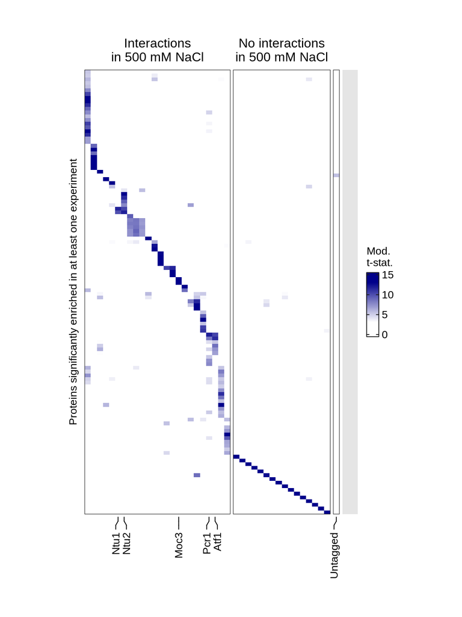

```r
hm2a <- Heatmap(hmdata_500$tstat,
                cluster_rows = FALSE,
                cluster_columns = FALSE,
                col = makeHeatmapCol(hmdata_500$tstat, stringency = "high"),
                border = TRUE,
                border_gp = gpar(lwd = 0.5),
                column_split = hmdata_500$colsplit,
                name = "Mod.\nt-stat.",
                na_col = binary_heatmap_colors["FALSE"],
                column_names_gp = gpar(fontsize = fs),
                row_names_gp = gpar(fontsize = fs),
                row_title = "Proteins significantly enriched in at least one experiment",
                row_title_gp = gpar(fontsize = fl),
                show_row_names = FALSE, show_column_names = FALSE,
                use_raster = FALSE, show_heatmap_legend = TRUE,
                right_annotation = makeComplexAnnotation(hmdata_500$tstat, complexes[complexLabel],
                                                         idmap = idmap, show_legend = FALSE),
                bottom_annotation = makeColLabels(hmdata_500$tstat, colLabel_500, fl),
                width = unit(w_ipmsHm, "mm"), # heatmap body width
                heatmap_height = unit(h_ipmsHm, "mm"), # whole heatmap height
                column_title_gp = gpar(fontsize = ft),
                heatmap_legend_param = list(title_gp = gpar(fontsize = fl),
                                border = "gray10",
                                border_gp = gpar(lwd = 0.5)))

hm_500 <- grid.grabExpr(
    hm2a <- draw(hm2a, merge_legend = TRUE,
                 heatmap_legend_side = "right",
                 annotation_legend_side = "right"),
    width = w_ipmsHm, height = h_ipmsHm
)

plot_grid(hm_500)
```

## Peak vs. sample heatmap (binary)

The following creates heatmap of peaks (rows) versus ChIP-seq experiments (columns). The values are binary (`TRUE` or `FALSE`) and indicate if a peak was enriched in ChIP-seq experiment (had an average log2 IP/input enrichment values greater than 1.0).

```r
# extract binary enrichment matrix from `peakgr`
m <- as.matrix(mcols(peakgr)[, grep("^is_enr_in[.]", colnames(mcols(peakgr)))])
mode(m) <- "numeric"
colnames(m) <- sub("is_enr_in.", "", colnames(m))

# specify ChIP-seq experiments for which to show labels
selLabels <- c("Untagged")
stopifnot(all(selLabels %in% colnames(m)))

# only show peaks that are enriched in at least one ChIP-seq experiment
sel_peaksBin <- rowSums(m) > 0

# prepare annotation data
#   `fractTFs`: fraction of ChIP-seq experiments that a peak is enriched in
#   `numpeaks`: the number of enriched peaks for each ChIP-seq experiment
#   `peaktype`: the type of each peak (specific, frequent or ubiquitous)
#   `near_ncRNA`: specifies if the peak is nearer than `maxdist` from
#                 a %S rRNA or tRNA gene
fracTFs <- rowMeans(m > 0)
numpeaks <- colSums(m > 0)
levels(peakgr$peaktype) <- c("Common (ubiquitous)", # use shorter names
                             "Common (frequent)",
                             "Specific peaks")
peaktype <- factor(gsub("[()]", "", sub(" ", "\n", peakgr$peaktype)),
                   levels = c("Common\nubiquitous",
                              "Common\nfrequent",
                              "Specific\npeaks"))
near_ncRNA <- factor(ifelse(!is.na(dist.peak2tRNA) & dist.peak2tRNA < maxdist,
                            "tRNA",
                            ifelse(!is.na(dist.peak2rRNA) & dist.peak2rRNA < maxdist,
                                   "5S rRNA", "none")),
                         levels = c("tRNA", "5S rRNA", "none"))

# most tRNA and 5S rRNA genes are near "common (ubiquitous)" peaks:
table(peaktype[sel_peaksBin], near_ncRNA[sel_peaksBin])
```

```
##
##                      tRNA 5S rRNA none
##   Common\nubiquitous  107      27  113
##   Common\nfrequent      1       0   93
##   Specific\npeaks       5       1 1148
```

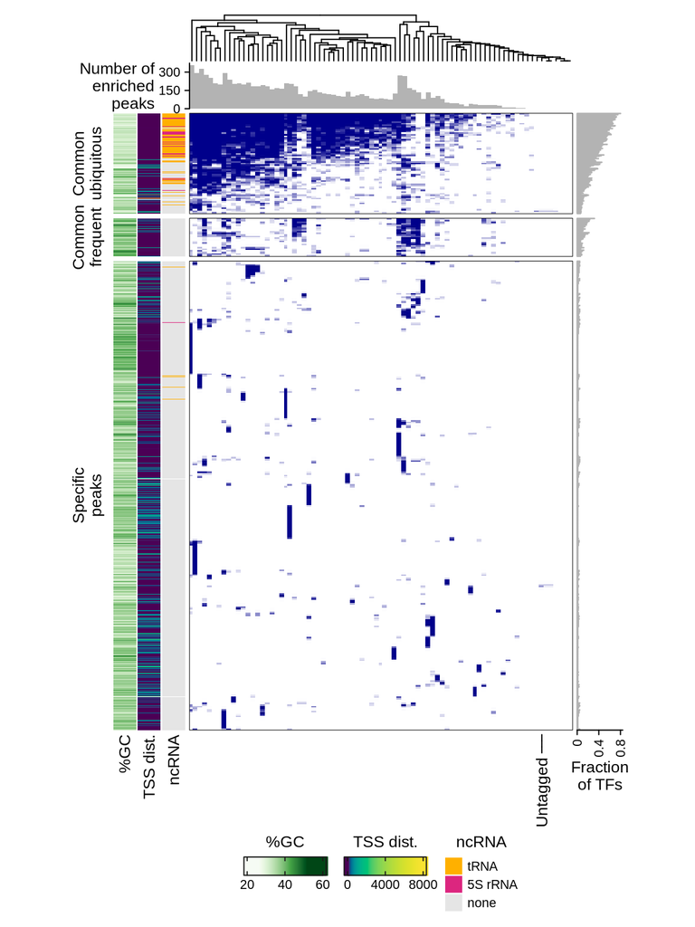

```r
# parameters for annotation legends and colors
annotLegendParams <- list(`%GC` = list(at = c(20, 40, 60),
                                       labels_gp = gpar(fontsize = fs),
                                       border = "gray10",
                                       legend_direction = "horizontal",
                                       legend_width = unit(18, "mm"),
                                       title_position = "topcenter",
                                       title_gp = gpar(fontsize = fl)),
                          `TSS dist.` = list(at = c(0, 4000, 8000),
                                             labels_gp = gpar(fontsize = fs),
                                             border = "gray10",
                                             legend_direction = "horizontal",
                                             legend_width = unit(18, "mm"),
                                             title_position = "topcenter",
                                             title_gp = gpar(fontsize = fl)),
                          `ncRNA` = list(labels_gp = gpar(fontsize = fs),
                                         title_position = "topcenter",
                                         title_gp = gpar(fontsize = fl)))
cols_ncRNA <- c("tRNA" = main_colors[5], "5S rRNA" = main_colors[3],
                "none" = bg_color)
annotCols <- list(
    `%GC` = colorRamp2(breaks = seq(min(peakgr$fracGC[sel_peaksBin]),
                                    max(peakgr$fracGC[sel_peaksBin]),
                                    length.out = 64) * 100,
                       colors = rev(hcl.colors(64, "Greens"))),
    ` width` = colorRamp2(breaks = seq(min(width(peakgr)[sel_peaksBin]),
                                       max(width(peakgr)[sel_peaksBin]),
                                       length.out = 64),
                          colors = rev(hcl.colors(64, "YlOrBr"))),
    `TSS dist.` = colorRamp2(breaks = c(0, 10^seq(2, log10(max(peakgr$nrst_TSS_dist)),
                                                  length.out = 63)),
                             colors = hcl.colors(64)),
    `ncRNA` = cols_ncRNA)

# prepare heatmap annotations
#   `peakAnnot` for peaks (rows), left side
#   `fracTFsAnnot` for peaks (rows), right side
#   `sampleAnnot` for ChIP-seq experiments (columns), top
#   `sampleLabels` for ChIP-seq experiments (columns), bottom
peakAnnot <- HeatmapAnnotation(
                  which = "row",
                  `%GC` = peakgr$fracGC[sel_peaksBin] * 100,
                  `TSS dist.` = peakgr$nrst_TSS_dist[sel_peaksBin],
                  `ncRNA` = near_ncRNA[sel_peaksBin],
                  col = annotCols,
                  width = unit(21, "mm"), show_legend = TRUE,
                  annotation_name_gp = gpar(fontsize = fl),
                  annotation_legend_param = annotLegendParams)

fracTFsAnnot <- HeatmapAnnotation(
    which = "row",
    `Fraction\nof TFs` = anno_barplot(
        x = fracTFs[sel_peaksBin], gp = gpar(col = na_color),
        border = FALSE, bar_width = 1.0,
        axis_param = list(at = c(0, 0.4, 0.8),
                          gp = gpar(fontsize = fs)),
        width = unit(10, "mm")),
    annotation_name_gp = gpar(fontsize = fl))
sampleAnnot <- HeatmapAnnotation(
    which = "column",
    `Number of\nenriched\npeaks` = anno_barplot(
        x = numpeaks,
        gp = gpar(col = 0, fill = na_color),
        border = FALSE, bar_width = 1.0,
        axis_param = list(at = c(0, 150, 300),
                          gp = gpar(fontsize = fs),
                          facing = "outside",
                          direction = "normal"),
        width = unit(10, "mm")),
    annotation_name_gp = gpar(fontsize = fl),
    annotation_name_side = "left", annotation_name_rot = 0,
    show_legend = TRUE)
sampleLabels <- columnAnnotation(
    TFnames = anno_mark(which = "column", side = "bottom",
                        at = match(selLabels, colnames(m)),
                        labels = sub("^[^_]+_", "", selLabels),
                        labels_gp = gpar(fontsize = fl)))

# create main heatmap with annotations
hm3 <- Heatmap(m[sel_peaksBin, ],
               col = circlize::colorRamp2(
                   breaks = seq(0, max(m), length.out = 64),
                   colors = colorRampPalette(binary_heatmap_colors[c("FALSE", "TRUE")])(64)),
               border = TRUE, border_gp = gpar(lwd = 0.5),
               cluster_rows = TRUE, row_dend_width = unit(25, "mm"), show_row_dend = FALSE,
               cluster_columns = TRUE, column_dend_height = unit(10, "mm"),
               row_title_gp = gpar(fontsize = fl),
               row_split = peaktype[sel_peaksBin], cluster_row_slices = FALSE,
               left_annotation = peakAnnot,
               right_annotation = fracTFsAnnot,
               top_annotation = sampleAnnot,
               bottom_annotation = sampleLabels,
               show_row_names = FALSE, show_column_names = FALSE,
               use_raster = TRUE, show_heatmap_legend = FALSE,
               width = unit(w_peaksHm, "mm"), # heatmap body width
               heatmap_height = unit(h_peaksHm, "mm")) # whole heatmap height

# draw the heatmap and grab as a grid graphics `grob`
# (needed for combining figure panels)
# use defined random number seed to make clustering deterministic
set.seed(42L)
hm_peaksBin <- grid.grabExpr(
    hm3 <- draw(hm3, merge_legend = TRUE,
                heatmap_legend_side = "bottom",
                annotation_legend_side = "bottom"),
    width = w_peaksHm, height = h_peaksHm
)

plot_grid(hm_peaksBin)
```

## Peak vs. sample heatmap (enrichments)

The following creates a heatmap similar to the peak-versus-experiment heatmap above, but using the ChIP-seq enrichment values (log2 IP/input) directly instead of binarized (`TRUE`, `FALSE`) values.

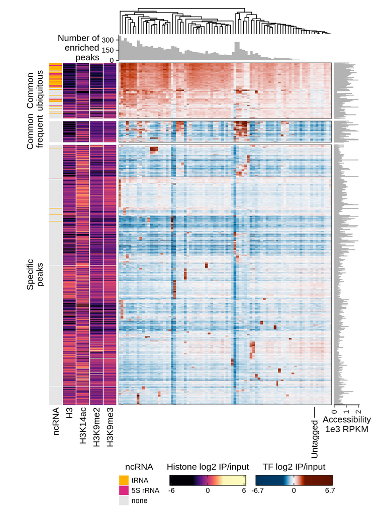

```r
# use ChIP-seq enrichment matrix from this study (replicates averaged)
m <- peakenrAvg
stopifnot(all(selLabels %in% colnames(m)))

# to keep the same row order as in the binary heatmap `hm3`,
# we have to re-calculate the annotations and switch off the row clustering
sel_peaksEnr <- which(sel_peaksBin)[unlist(row_order(hm3), use.names = FALSE)]

# prepare annotation data
#   `chip_enr_sel`: selected public ChIP-seq experiments
#                   (log2 IP/input enrichments)
#   `chip_enr_sel_range`: value range for color scale (1% to 99%)
#   `chip_enr_sel_range_full`: value range for color scale (0% to 100%)
chip_enr_sel <- chip_enr[sel_peaksEnr, ]
chip_enr_sel_range <- quantile(abs(chip_enr_sel), probs = c(0.95)) * c(-1, 1)
chip_enr_sel_range_full <- range(chip_enr_sel)

# parameters for annotation legends and colors
annotCols2 <- list(
    `ncRNA` = cols_ncRNA,
    H3 = colorRamp2(breaks = c(chip_enr_sel_range_full[1],
                               seq(chip_enr_sel_range[1],
                                   chip_enr_sel_range[2],
                                   length.out = 62),
                               chip_enr_sel_range_full[2]),
                    colors = viridisLite::magma(64)),
    H3K14ac = colorRamp2(breaks = c(chip_enr_sel_range_full[1],
                                    seq(chip_enr_sel_range[1],
                                        chip_enr_sel_range[2],
                                        length.out = 62),
                                    chip_enr_sel_range_full[2]),
                         colors = viridisLite::magma(64)),
    H3K9me2 = colorRamp2(breaks = c(chip_enr_sel_range_full[1],
                                    seq(chip_enr_sel_range[1],
                                        chip_enr_sel_range[2],
                                        length.out = 62),
                                    chip_enr_sel_range_full[2]),
                         colors = viridisLite::magma(64)),
    H3K9me3 = colorRamp2(breaks = c(chip_enr_sel_range_full[1],
                                    seq(chip_enr_sel_range[1],
                                        chip_enr_sel_range[2],
                                        length.out = 62),
                                    chip_enr_sel_range_full[2]),
                         colors = viridisLite::magma(64)))
annotLegendParams2 <- list(
    `ncRNA` = list(labels_gp = gpar(fontsize = fs),
                   title_position = "topcenter",
                   title_gp = gpar(fontsize = fl)),
    H3 = list(at = c(-6, 0, 6),
              title = "Histone log2 IP/input",
              labels_gp = gpar(fontsize = fs),
              border = "gray10",
              legend_direction = "horizontal",
              legend_width = unit(30, "mm"),
              title_position = "topcenter",
              title_gp = gpar(fontsize = fl)))

# prepare heatmap annotations
#   `peakAnnot` for peaks (rows), left side
#   `peakAnnot2` for peaks (rows), right side
peakAnnot <- HeatmapAnnotation(
                  which = "row",
                  `ncRNA` = near_ncRNA[sel_peaksEnr],
                  H3 = chip_enr_sel[, "GSE108668_H3"],
                  H3K14ac = chip_enr_sel[, "GSE108668_H3K14ac"],
                  H3K9me2 = chip_enr_sel[, "GSE182250_H3K9me2"],
                  H3K9me3 = chip_enr_sel[, "GSE182250_H3K9me3"],
                  col = annotCols2,
                  width = unit(28, "mm"),
                  annotation_name_gp = gpar(fontsize = fl),
                  annotation_legend_param = annotLegendParams2,
                  show_legend = c(TRUE, TRUE, FALSE, FALSE, FALSE))
atac_trunc <- pmin(atac_rpkm_avg[sel_peaksEnr], 2000) # cap ATAC signal at 2000
peakAnnot2 <- HeatmapAnnotation(
    which = "row",
    `Accessibility\n1e3 RPKM` =
        anno_barplot(x = atac_trunc / 1e3,
                     gp = gpar(col = na_color),
                     border = FALSE, bar_width = 1.0,
                     baseline = 0,
                     axis_param = list(at = c(0, 1, 2),
                                       gp = gpar(fontsize = fs)),
                     width = unit(10, "mm")),
    annotation_name_gp = gpar(fontsize = fl))

# main heatmap value range for color scale
mx <- max(abs(m[sel_peaksEnr, ]))
qs <- quantile(abs(m[sel_peaksEnr, ]), .99)

# create main heatmap with annotations
hm4 <- Heatmap(m[sel_peaksEnr, ], name = "log2 IP/input",
               col = circlize::colorRamp2(
                   breaks = c(-mx, seq(-qs, qs, length.out = 62), mx),
                   colors = colorRampPalette(enrichment_heatmap_colors)(64)),
               cluster_rows = FALSE,
               cluster_columns = column_dend(hm3), column_dend_height = unit(10, "mm"),
               row_title_gp = gpar(fontsize = fl),
               row_split = peaktype[sel_peaksEnr], cluster_row_slices = FALSE,
               border = TRUE, border_gp = gpar(lwd = 0.5),
               left_annotation = peakAnnot,
               right_annotation = peakAnnot2,
               top_annotation = sampleAnnot,
               bottom_annotation = sampleLabels,
               show_row_names = FALSE, show_column_names = FALSE,
               use_raster = TRUE, show_heatmap_legend = TRUE,
               heatmap_legend_param = list(at = round(c(-mx, 0, mx), 1),
                                           labels_gp = gpar(fontsize = fs),
                                           border = "gray10",
                                           legend_direction = "horizontal",
                                           legend_width = unit(30, "mm"),
                                           title = "TF log2 IP/input",
                                           title_position = "topcenter",
                                           title_gp = gpar(fontsize = fl)),
               width = unit(w_peaksHm, "mm"), # heatmap body width
               heatmap_height = unit(h_peaksHm, "mm"))

# draw the heatmap and grab as a grid graphics `grob`
# (needed for combining figure panels)
# use defined random number seed to make clustering deterministic
set.seed(42L)
hm_peaksEnr <- grid.grabExpr(
    hm4 <- draw(hm4, merge_legend = TRUE,
                heatmap_legend_side = "bottom",
                annotation_legend_side = "bottom"),
    width = w_peaksHm, height = h_peaksHm
)

plot_grid(hm_peaksEnr)
```

## ChIP enrichment replicate-pair correlations

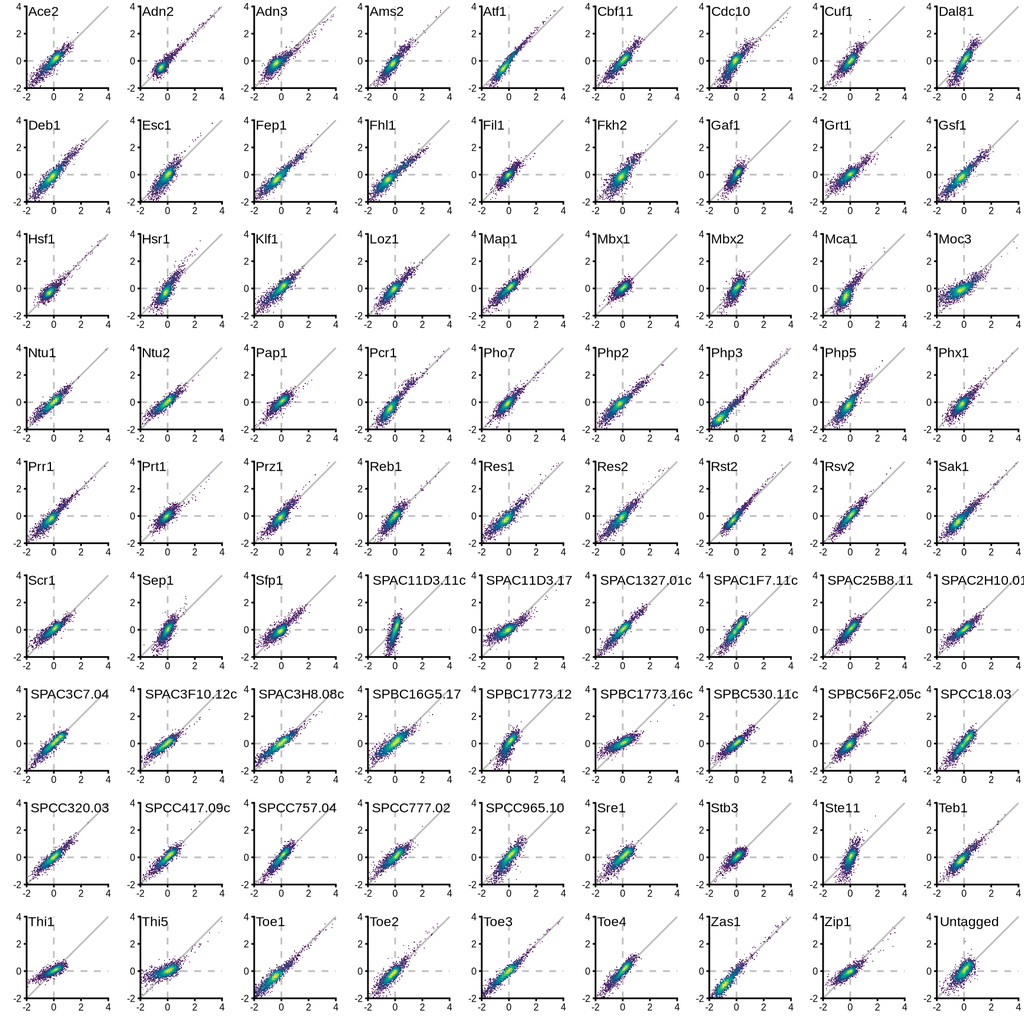

```r
pd <- peakenr |> as.data.frame() |>
    tibble::rownames_to_column("peakid") |>
    pivot_longer(col = !matches("peakid")) |>
    mutate(group = sub("_rep[12]$", "", name),
           name = factor(name, levels = unique(name)))

ylims <- c(-2.0, 4.0)
yticks <- c(-2, 0, 2, 4)

pL <- lapply(levels(fct_relevel(sort(unique(pd$group)), "Untagged", after = Inf)),
             function(grp1) {
    pd1 <- pd[pd$group == grp1, ] |> pivot_wider()
    pd1$cols <- densCols(x = pd1[[paste0(grp1, "_rep1")]],
                         y = pd1[[paste0(grp1, "_rep2")]],
                         nbin = 64, colramp = colorRampPalette(hcl.colors(32)))
    ggplot(pd1, aes(.data[[paste0(grp1, "_rep1")]],
                    .data[[paste0(grp1, "_rep2")]])) +
        geom_abline(intercept = 0, slope = 1, linetype = 1, color = "gray") +
        geom_hline(yintercept = 0, linetype = 2, color = "gray") +
        geom_vline(xintercept = 0, linetype = 2, color = "gray") +
        geom_scattermost(xy = as.data.frame(pd1[, paste0(grp1, c("_rep1", "_rep2"))]),
                         pointsize = 2, color = pd1$cols, pixels = c(256, 256)) +
        coord_fixed(xlim = ylims, ylim = ylims, expand = FALSE, clip = "off") +
        scale_x_continuous(breaks = yticks) +
        scale_y_continuous(breaks = yticks) +
        theme_cowplot(7) +
        labs(x = element_blank(), y = element_blank()) +
        annotate("text", x = -Inf, y = Inf, hjust = -0.05, vjust = 1.05,
                 label = grp1, color = "black", size = 3) +
        theme(legend.position = "none")
})

(gg_enrpairs <- plot_grid(plotlist = pL, nrow = 9, ncol = 9))
```

## Put together

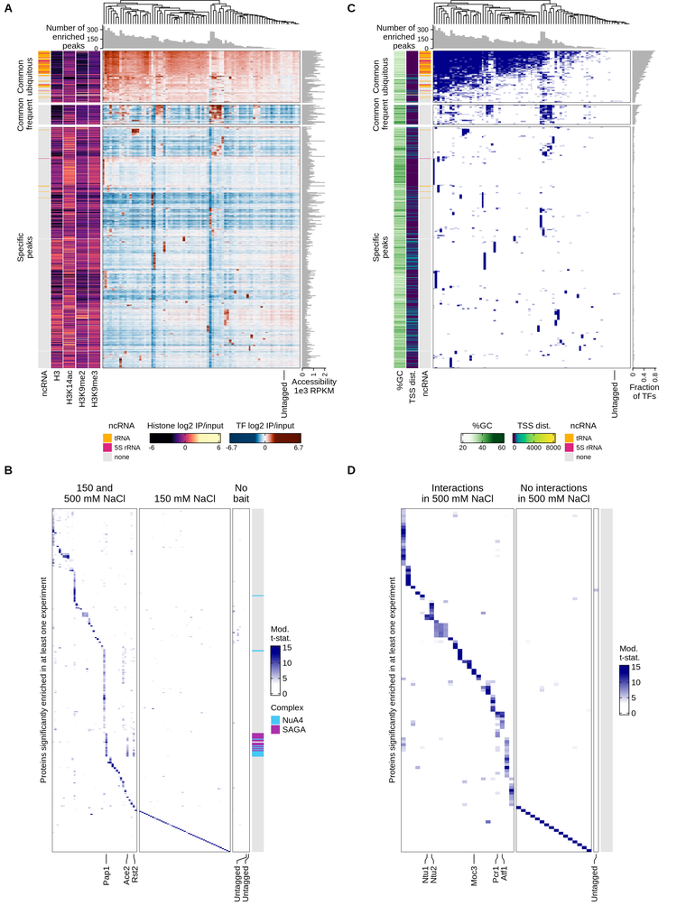

```r
cowplot::plot_grid(
    hm_peaksEnr,
    hm_peaksBin,
    hm_150,
    hm_500,
    nrow = 2,
    labels = c("A", "C", "B", "D"),
    align = "v",
    axis = "b"
)
```

## Supplementary figure

Assemble the panels into Supplementary Figure 2:

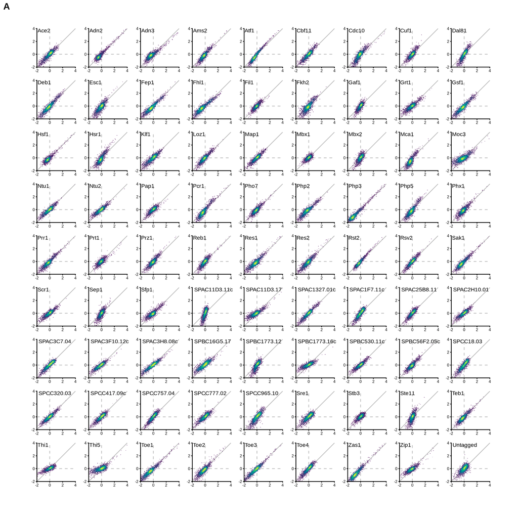

```r
cowplot::plot_grid(
    gg_enrpairs,
    scale = 0.9,
    labels = "A"
)
```